# Final Report

Final Project  
Data Science 1 with R (STAT 301-1)

Author

Fiona Liu

Published

December 9, 2025

**TipGithub Repo Link**

[Fiona’s Github](https://github.com/stat301-1-2025-fall/final-project-1-fionaliu0105)

## Introduction

Language is often perceived as purely qualitative, yet psycholinguistics provides frameworks to quantify the emotional weight of our vocabulary. By mapping words onto a multi-dimensional space, we can transform subjective feelings into objective data points. This project conducts an Exploratory Data Analysis (EDA) on the *Warriner et al. (2013)* dataset, a comprehensive collection of affective norms for nearly 14,000 English lemmas.

The objective of this analysis is to move beyond simple positive/negative sentiment tracking. Instead, I explore the structural relationships between three distinct emotional dimensions: Valence (pleasantness), Arousal (intensity), and Dominance (control). Furthermore, this report investigates how external factors—specifically the gender of the rater and the grammatical structure of the word—modulate our perception of these emotions.

## Data Overview & Quality

The data used in this report is derived from *Norms of valence, arousal, and dominance for 13,915 English lemmas* (Warriner et al., 2013). The dataset contains mean ratings gathered from extensive human trials where participants rated words on a 1-9 scale for:

- Valence: The pleasantness of the stimulus (1 = Unhappy, 9 = Happy).
- Arousal: The intensity of the feeling evoked (1 = Calm, 9 = Excited).
- Dominance: The degree of control felt by the rater (1 = Controlled, 9 = In Control).

The dataset consists of 13,915 observations and 63 variables. The data quality is high; a check for missingness reveals no missing values in the primary variables of interest.

Table 1 below provides a high-level summary of the rating scales.

Table 1: Summary Statistics of Emotional Dimensions (Scale 1-9)

Descriptive Statistics of Affective Dimensions

| Variable | Mean | Median | Std. Dev. | Min | Max |
| --- | --- | --- | --- | --- | --- |
| Valence | 5.06 | 5.20 | 1.27 | 1.26 | 8.53 |
| Arousal | 4.21 | 4.11 | 0.90 | 1.60 | 7.79 |
| Dominance | 5.18 | 5.26 | 0.94 | 1.68 | 7.90 |

## Explorations

### Univariate Analysis: Distributions

My first objective was to understand the shape of the three main emotional dimensions. Do they follow similar patterns?

Figure 1 displays the distributions for Valence, Arousal, and Dominance side-by-side.

- **Arousal (Blue):** This distribution is **right-skewed**. The peak is concentrated at the lower end of the scale (between 3 and 4), indicating that the majority of words in the English lexicon are perceived as relatively “calm” or low-intensity. High-excitement words are comparatively rare.
- **Dominance (Red):** This distribution is the most “peaked” and is centered slightly above the neutral mark (around 5.5). This suggests that for most words, participants feel a moderate to high sense of control.
- **Valence (Purple):** This shows the most variation. While roughly bell-shaped, it is centered slightly on the positive side (above 5). This aligns with the “Pollyanna Principle” in linguistics, where languages tend to contain more positive words than negative ones.

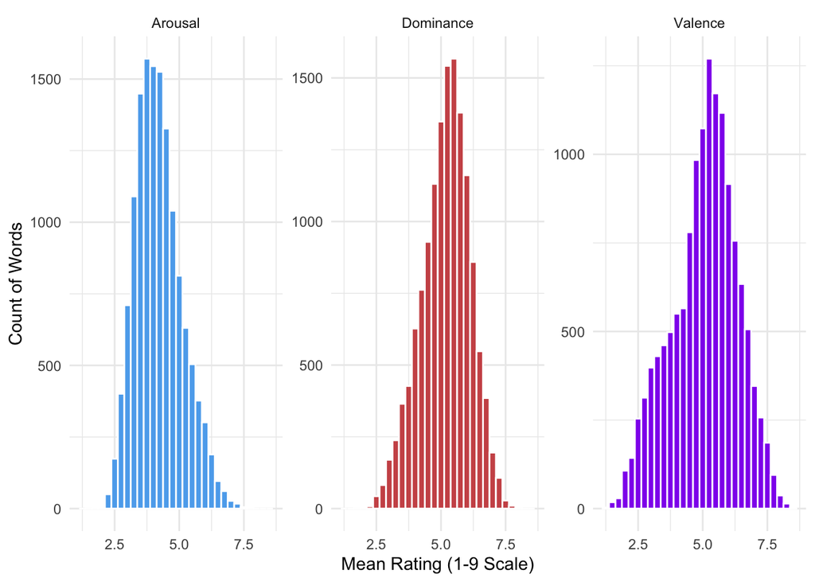

Figure 1: Distributions of the three affective dimensions. Valence is bell-shaped, while Arousal and Dominance show slight skew.

### Correlation Analysis

Before visualizing specific relationships, I examined the Pearson correlations among the three dimensions. As visualized in Figure 2, Valence and Dominance share a strong positive relationship ($r = 0.72$). This suggests that more pleasant words also tend to be associated with a greater sense of control. In contrast, Arousal shows weak linear correlations with the other dimensions (lighter colors).

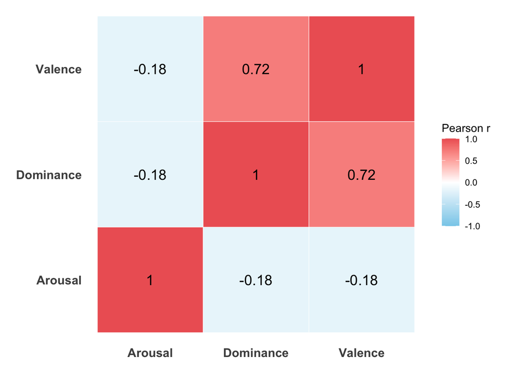

Figure 2: Heatmap of Pearson Correlations. Red indicates positive correlation; Blue indicates negative. The numbers represent the correlation coefficient (r).

### Bivariate Analysis: The “Boomerang” of Intensity

How do pleasantness and intensity relate? One might hypothesize a linear relationship, but the data suggests a more complex dynamic.

Figure 3 visualizes the relationship between Valence and Arousal. We observe a distinct U-shaped (or boomerang) relationship. Words that are highly unpleasant (Valence < 3) and highly pleasant (Valence > 7) both correlate with high Arousal. It is the “neutral” words (Valence ~5) that are the least arousing.

This suggests that emotional neutrality is synonymous with calmness, while strong emotion—regardless of whether it is good or bad—is inherently intense.

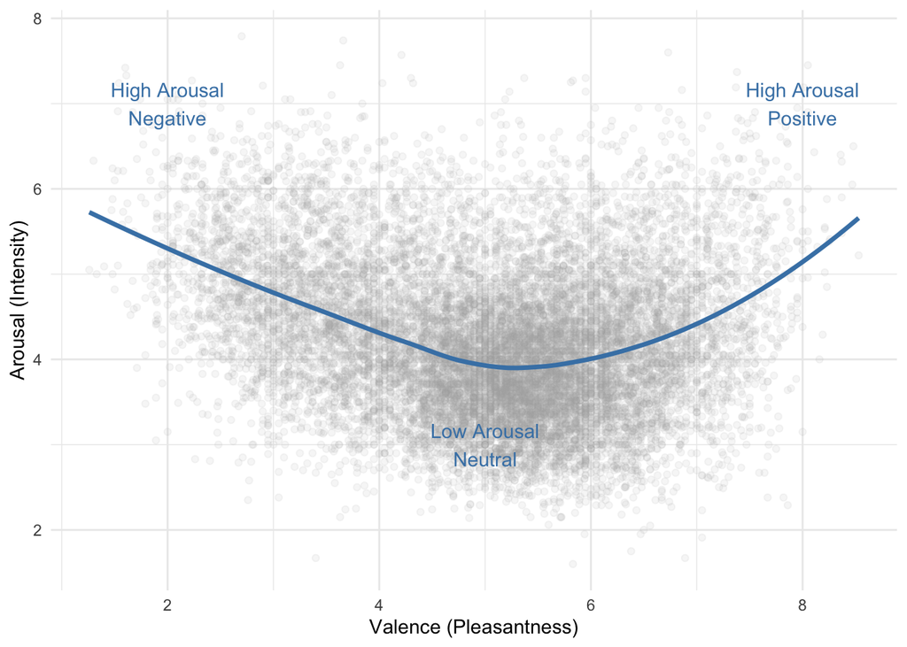

Figure 3: The ‘Boomerang’ Effect: Relationship between Valence and Arousal. The curve (LOESS smoothing) highlights that arousal is lowest for neutral words and increases at emotional extremes.

### Demographic Analysis: The Gender Gap in Perception

A critical component of the Warriner et al. dataset is the segmentation of raters by gender. Do men and women perceive concepts differently?

#### Distribution Comparison

In Figure 4, I overlaid the density distributions to examine how men and women utilize the 1-9 rating scale differently.

- **Similarities (Valence & Dominance)**: The distributions for Valence and Dominance show a high degree of overlap between genders. Both groups follow the same general trends, peaking at the same points. This suggests that men and women share a very similar distinct sense of what is “pleasant” and what represents “control.”
- **The Divergence (Arousal)**: The most distinct gender difference appears in Arousal. The Male distribution is shifted noticeably to the right compared to the Female distribution. This indicates a systematic difference: men generally rate words as having higher intensity (arousal) than women do, while women utilize the lower end of the arousal scale more frequently.

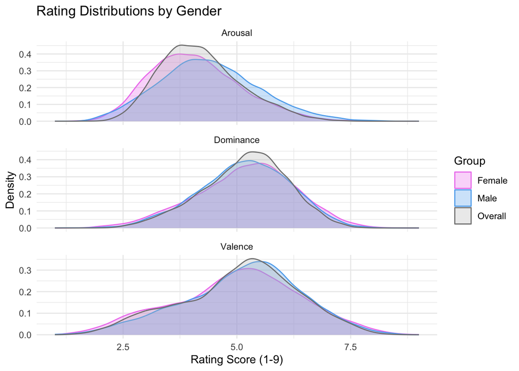

Figure 4: Density Comparison: Male vs. Female vs. Overall Average across all dimensions.

To quantify this visual shift in Arousal, I calculated the aggregate mean difference between the groups. As seen in Table 2, men rated words on average 0.29 points higher on the intensity scale than women, a consistent systemic difference across the lexicon.

Table 2: Aggregate Gender Difference in Arousal Ratings

| Avg. Male Arousal | Avg. Female Arousal | Net Difference |
| --- | --- | --- |
| 4.38 | 4.10 | 0.29 |

To further quantify this divergence, I compared the mean ratings for Males vs. Females directly. In Figure 5, the solid black line represents the Identity Line ($y=x$), where points would fall if genders agreed perfectly.

**Findings:**

1. Valence & Dominance: These plots show tight clustering around the identity line, confirming that men and women largely agree on the pleasantness and dominance of words.
2. Arousal: This plot confirms the trend seen in the density analysis. The cloud of points is shifted slightly below the line (towards the Male axis). This visual shift confirms that for the same word, the Male rating is consistently higher than the Female rating.

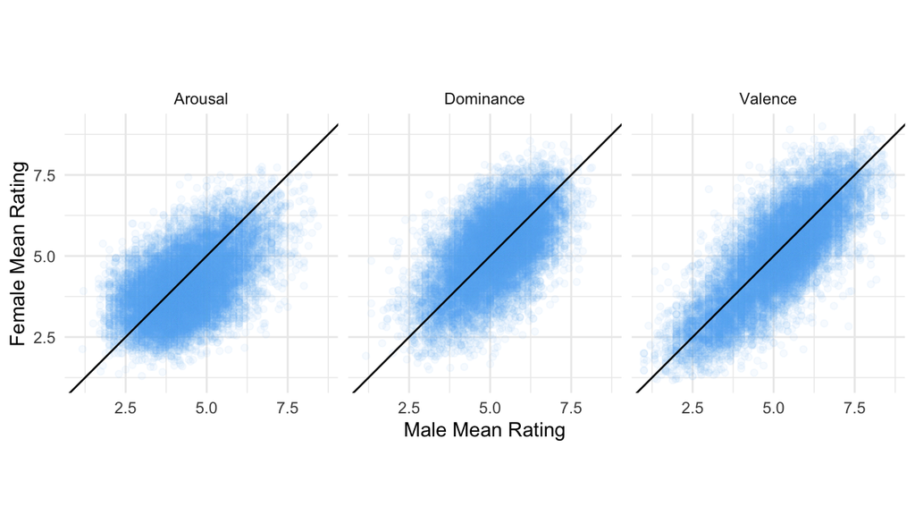

Figure 5: Comparison of Mean Ratings by Gender. The line represents perfect agreement (y=x).

#### Identification of Disagreement

To make this actionable, we can identify specific words where gender disagreement is highest. I calculated the difference between Male and Female arousal ratings (`Diff = Male - Female`).

Table 3 shows words where men felt significantly more intense (Arousal) than women, and vice versa. Notably, men found traditional “vice” or conflict-related words (musket, Jack Daniels) more arousing, while women reported higher intensity for words related to family, social dynamics as well as stereotypical expectations for women (toddler, gigolo, skinny).

Table 3: Top Words with Gender Disagreement in Arousal

| Word | Male Score | Female Score | Difference |
| --- | --- | --- | --- |
| Men felt more intense |  |  |  |
| musket | 6.83 | 2.58 | 4.25 |
| oral | 7.50 | 3.43 | 4.07 |
| nomad | 6.17 | 2.17 | 4.00 |
| barmaid | 6.78 | 2.82 | 3.96 |
| Jack Daniels | 6.67 | 2.73 | 3.94 |
| Women felt more intense |  |  |  |
| pop | 1.80 | 5.38 | −3.58 |
| seafood | 2.70 | 6.00 | −3.30 |
| toddler | 2.73 | 6.00 | −3.27 |
| gigolo | 2.00 | 5.19 | −3.19 |
| skinny | 2.40 | 5.44 | −3.04 |

### Linguistic Analysis: The Grammar of Control

Finally, I investigated if the grammatical form of a word influences its emotional weight. Specifically, I hypothesized that active verbs would carry a stronger sense of Dominance (Control) than abstract nouns, as verbs imply agency and action.

I used regular expressions to tag words based on suffixes:

- `"-tion"`: Typically abstract nouns (e.g., abstraction, notion).
- `"-ize"`: Typically active verbs (e.g., terrorize, mobilize).

Figure 6 compares the Dominance ratings for these two groups. The boxplot clearly shows that “-ize” verbs have a higher median Dominance rating than “-tion” nouns. This suggests that action-oriented language is perceived as having more agency and control than abstract state-of-being nouns.

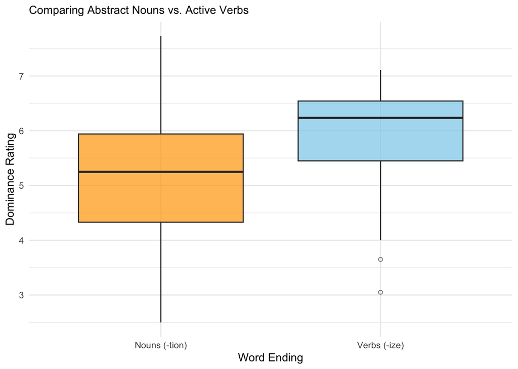

Figure 6: Dominance Ratings by Word Suffix. Verbs ending in ‘-ize’ show higher median dominance than nouns ending in ‘-tion’.

### Ambiguity Analysis: The Most Controversial Words

While mean ratings provide the “average” feeling of a word, they hide the spread of opinions. A high Standard Deviation (SD) indicates **ambiguity** or **disagreement**—meaning some people rated the word very high while others rated it very low.

I created a custom function `get_top_ambiguous()` to efficiently identify the top 5 words with the highest disagreement for each dimension.

Table 4 displays these “controversial” words.

- **Valence Disagreement:** This list is dominated by taboo terms and “religion.” This reflects that some raters likely perceive these words as highly offensive, while others view them as neutral, empowering, or positive.
- **Arousal Disagreement:** High variability appears in subjective concepts like “favorite” and “dreamland”. The intensity of these words likely depends heavily on individual personal experiences.
- **Dominance Disagreement:** Words related to vices and external forces top this list, such as “cigarette,” “management,” and “crowd.” The disagreement here suggests a split in perceived agency: for example, a “cigarette” might represent a controllable object to some, but a controlling addiction to others.

Table 4: Top 5 Most Ambiguous Words (Highest Standard Deviation) by Dimension

| Word<sup>1</sup> | Mean Score | Std. Dev. (Disagreement) |
| --- | --- | --- |
| Valence (Pleasantness) |  |  |
| f***ing | 5.09 | 3.29 |
| f*** | 5.23 | 3.25 |
| porno | 5.53 | 3.12 |
| religion | 5.42 | 3.08 |
| sh*tfaced | 4.65 | 3.08 |
| Arousal (Intensity) |  |  |
| favorite | 4.40 | 3.36 |
| dreamland | 3.95 | 3.33 |
| bitter | 4.64 | 3.30 |
| lovemaking | 6.14 | 3.29 |
| prince | 5.15 | 3.28 |
| Dominance (Control) |  |  |
| cigarette | 5.05 | 3.37 |
| management | 4.70 | 3.32 |
| crowd | 5.21 | 3.29 |
| enforcer | 5.36 | 3.26 |
| cannibalism | 4.09 | 3.22 |

<sup>1</sup> Explicit terms have been masked for professional presentation, but remain part of the statistical analysis.

## Conclusion

This exploratory analysis of the Warriner et al. dataset has effectively mapped the emotional structure of the English lexicon, revealing that our perception of words is not random, but follows distinct psychological and linguistic patterns.

**Key Insights:**

- **The Shape of Emotion:** We confirmed the “Pollyanna Principle,” observing that the English language is positively biased. However, we also established that emotional neutrality is synonymous with calmness; the “U-shaped” relationship between Valence and Arousal demonstrates that as words become more positive *or* more negative, they inherently become more intense.
- **The Gender Gap in Intensity:** Perhaps the most significant finding was the systemic divergence in **Arousal**. While men and women largely agree on whether a word is pleasant (Valence) or controlling (Dominance), men consistently rate words as having higher intensity than women. This suggests a fundamental difference in how genders anchor their perception of excitement or alertness.
- **The Grammar of Agency:** The linguistic analysis successfully linked grammatical form to emotional weight. By confirming that active verbs (ending in *-ize*) carry higher Dominance scores than abstract nouns (ending in *-tion*), we demonstrated that the structure of a word contributes to its perceived level of agency.
- **The Nature of Controversy:** Our ambiguity analysis revealed that consensus breaks down most frequently around taboo topics. Profanity and religion drive the highest disagreement in Valence, while subjective experiences drive disagreement in Arousal.

**Limitations & Confounds:**

It is important to acknowledge potential confounds in this analysis. First, the data relies on a North American sample, meaning the emotional ratings are culturally specific and may not generalize to other English-speaking populations (e.g., UK, Australia). Additionally, variables such as word familiarity and concreteness were not controlled for in this specific EDA; it is possible that abstract words generally receive lower dominance ratings regardless of their grammatical suffix.

**Future Work:** While this project analyzed words in isolation (lemmas), language rarely exists without context. Future analyses could benefit from:

1. **Contextual Sentiment Analysis:** Integrating this dictionary with natural language text (e.g., social media feeds or literature) to see if the gender gap in Arousal persists when words are used in full sentences.
2. **Part-of-Speech Expansion:** expanding the linguistic analysis beyond specific suffixes to compare all nouns, verbs, and adjectives to see if “part of speech” is a reliable predictor of Dominance.
3. **Cross-Cultural Comparison:** Comparing this dataset with Spanish or Dutch affective norms (available in similar psycholinguistic databases) to investigate if the “Gender Gap in Arousal” is a universal human trait or a cultural artifact of North American society.

## References

Warriner, A. B., Kuperman, V., & Brysbaert, M. (2013). Norms of valence, arousal, and dominance for 13,915 English lemmas. *Behavior Research Methods*, 45(4), 1191–1207.